CAMPAIGN 2027 — FIRST CAPTAIN

# EASTON ZUEGER

Cadet · United States Military Academy · Class of 2027

## LEAD FROM THE FRONT.

Scholar. Athlete. Leader. From the ice at Michie Arena to the mountains of Italy, Easton Zueger has never once taken a shift off. Now he's asking for the biggest responsibility the Corps has to offer — and his record says he's ready.

3

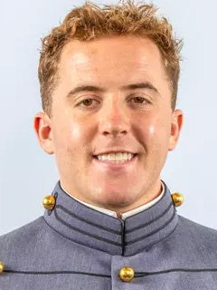

★ JANUARY SCHOLAR-ATHLETE OF THE MONTH ★ 77 BLOCKED SHOTS ★ AHCA ALL-AMERICAN SCHOLAR ★ KEARNEY CONSULTING INTERN ★ 173RD AIRBORNE CTLT VICENZA ITALY ★ SCUBA CERTIFIED ★ ELK POINT SOUTH DAKOTA ★ ARMY HOCKEY #3 ★ LEAD FROM THE FRONT ★

77

Blocked shots sophomore year

★

AHCA All-American Scholar

1st

Captain of the Corps

// THE CASE

## WHY ZUEGER

🏈

Iron on the Ice

You don't rack up 77 blocked shots in a single season by accident. You do it by putting your body in front of danger so your teammates don't have to. That's not a hockey stat — that's a leadership philosophy.

📚

Scholar First

AHCA All-American Scholar. AHA All-Academic Team. January Scholar-Athlete of the Month. His TAC officer called him "professional, generous, and always willing to help others." He doesn't just meet the standard. He raises it.

🌍

Global Experience

Most cadets spend their summer on post. Easton spent his in Vicenza, Italy as a Platoon Sergeant with the 173rd Airborne. Then pivoted to a management consulting internship at Kearney. Equally lethal in both arenas.

⚡

Earned, Not Granted

Elk Point, South Dakota doesn't produce many D1 athlete-scholars. From the Sioux City Musketeers to Army Black Knights, everything Easton has he built himself. He knows what it means to work for something from nothing.

🥀

🎯

Already a Role Model

His TAC officer said it plainly: "others look to him as a role model." You don't get to be a role model — it's earned by how you carry yourself when nobody's watching. Easton has been carrying himself that way since Day 1.

"His maturity sets him apart from his peers and his dedication in all pillars is noticeable — he only makes the Corps better as others look to him as a role model."

— COMPANY TACTICAL OFFICER, USMA · JANUARY 2025

// FULL DOSSIER

## THE RECORD

01AHCA All-American Scholar — HockeyACADEMIC

02AHA All-Academic Team SelectionACADEMIC

03January Scholar-Athlete of the Month, USMA CEPAWARD

0477 Blocked Shots, Sophomore Season — Career-best 6 in AHA TournamentATHLETICS

05CTLT — A/1-173 IN, Vicenza, Italy · Platoon SergeantLEADERSHIP

06AIAD Intern, Kearney Management ConsultingPROFESSIONAL

07DPE Scuba PIAD — Certified Combat Diver CandidateSKILLS

08USMA Project's Day 2025 — Research PresenterRESEARCH

09Army West Point Hockey — #3, Defense, 36 Career GamesATHLETICS

10Former Sioux City Musketeers (USHL) — Earned D1 CommitBACKGROUND

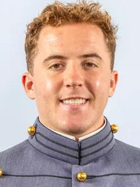

"Professional.  
Generous.  
Always willing  
to help."

// COMMITMENTS

## THE PLATFORM

01

Cadet Welfare, No Asterisks

The Corps runs on people. A First Captain who has been in the trenches — on the ice, in the weight room, at 0530 formation — understands what the Corps actually needs. Easton will fight for quality-of-life improvements that have real impact.

02

Hold the Standard, Earn the Respect

Standards at West Point exist for a reason. Easton believes in enforcing the standard not through fear but through example. When your First Captain has blocked 77 shots in a season and aced every class, the standard feels like a baseline.

03

Bridge Between Corps and Staff

The First Captain's most important job is translation — making sure the concerns of 4,400 cadets reach the people who can act on them. Easton's consulting experience taught him how to synthesize complex problems into clear recommendations.

04

Compete Everywhere, Represent Always

The First Captain is the face of 4,400 cadets to the Army, the nation, and the world. Easton has already represented West Point in Italy, in consulting boardrooms, on research stages, and in Division I arenas. He knows how to show up.

// FROM THE CORPS

## ENDORSEMENTS

★★★★★

"I've played alongside a lot of guys who talk about sacrifice. Easton is one of the few who actually practices it — every shift, every block, every study hall. The Corps deserves that kind of captain."

CDT J. BROWER

Army Hockey Teammate

★★★★★

"When Zueger walked into that Kearney office, he outworked interns who had been prepping for consulting their entire career. He makes every room he walks into perform better."

KEARNEY INTERN COHORT

AIAD Summer Program · 2025

★★★★★

"The 173rd has hosted a lot of CTLT cadets. Easton was different. He didn't just observe — he led. The NCOs respected him before the first week was out. That kind of credibility isn't taught. It's earned."

CADRE, A/1-173 IN

Vicenza, Italy · CTLT 2024

// NOVEMBER 2026

## LEAD FROM THE FRONT

The Corps doesn't just need a figurehead — it needs someone who has already proven they'll take the hit so others don't have to. Easton Zueger for First Captain, 2027.

I'M WITH ZUEGER